# Visualisation_Dhruv_K_21BAI1604

## Assignment 8th September (Data Visualisation)

### Dhruv Karmokar (21BAI1604)

```python
import numpy as np
import pandas as pd
import seaborn as sns
import matplotlib.pyplot as plt
```

```python
df = sns.load_dataset("car_crashes")
df.head()
```

|  | total | speeding | alcohol | not_distracted | no_previous | ins_premium | ins_losses | abbrev |
| --- | --- | --- | --- | --- | --- | --- | --- | --- |
| 0 | 18.8 | 7.332 | 5.640 | 18.048 | 15.040 | 784.55 | 145.08 | AL |
| 1 | 18.1 | 7.421 | 4.525 | 16.290 | 17.014 | 1053.48 | 133.93 | AK |
| 2 | 18.6 | 6.510 | 5.208 | 15.624 | 17.856 | 899.47 | 110.35 | AZ |
| 3 | 22.4 | 4.032 | 5.824 | 21.056 | 21.280 | 827.34 | 142.39 | AR |
| 4 | 12.0 | 4.200 | 3.360 | 10.920 | 10.680 | 878.41 | 165.63 | CA |

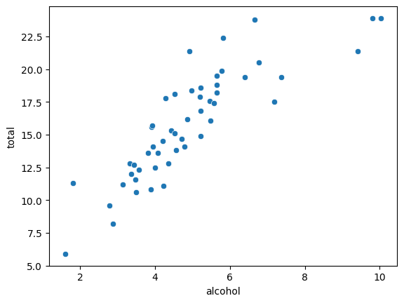

```python
sns.scatterplot(x='alcohol', y='total', data=df)
```

This scatter plot shows the relationship between alcohol consumption and total crashes. You can infer whether there is a linear or non-linear relationship, and whether there are any outliers.

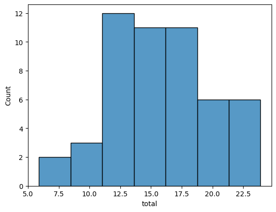

```python
sns.histplot(df['total'])
```

This histogram shows the distribution of total crashes. You can infer the most common range of total crashes and whether there are any outliers.

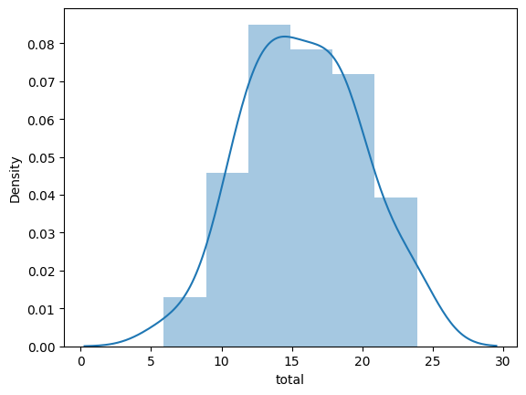

```python
sns.distplot(df['total'])
```

This plot provides a histogram along with a probability density curve. You can infer the distribution of total crashes, whether it's normal or skewed, and any potential outliers.

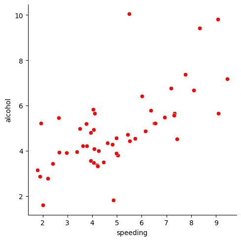

```python
sns.relplot(x='speeding', y='alcohol', data=df, color='red')
```

This plot displays the relationship between speeding and alcohol consumption. You can infer whether there is any correlation or pattern between these two variables.

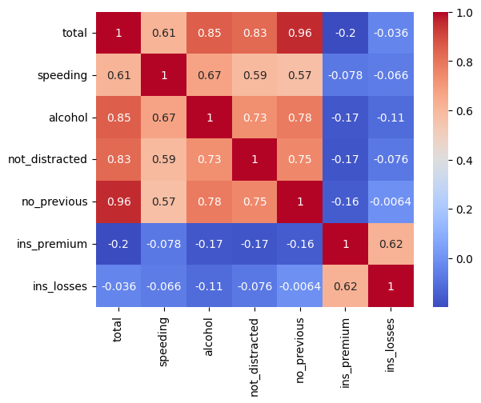

```python
sns.heatmap(df.corr(), annot=True, cmap='coolwarm')
```

The heatmap shows the correlation between numeric variables. You can identify which variables are strongly correlated, which can help in making predictions. For example, you can see if there's a strong positive correlation between 'alcohol' and 'total' crashes.

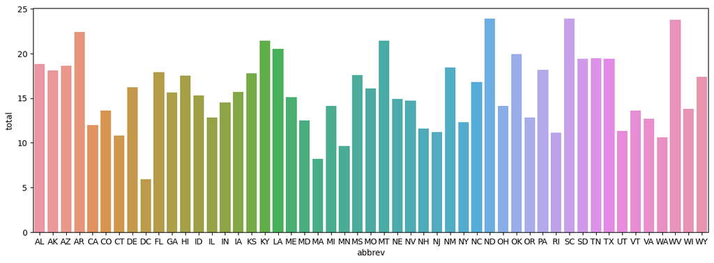

```python
fig, ax = plt.subplots(figsize=(15, 5))
sns.barplot(x='abbrev', y='total', data=df, ax=ax)
```

This barplot displays the average total crashes for each state. You can easily compare the crash rates between states and identify which state has the highest average.

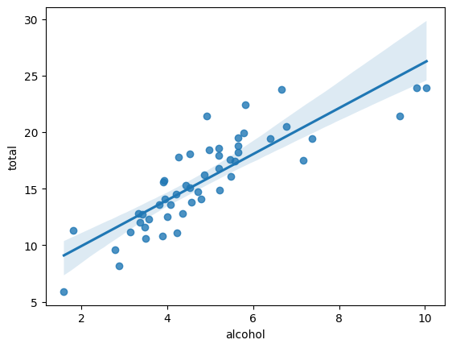

```python
sns.regplot(x='alcohol', y='total', data=df)
```

This plot shows the relationship between alcohol consumption and total crashes. You can infer whether there's a positive or negative correlation between these variables.

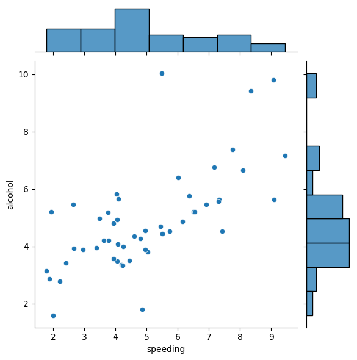

```python
sns.jointplot(x='speeding', y='alcohol', data=df, kind='scatter')
```

The joint plot combines a scatter plot and histograms to show the relationship between speeding and alcohol consumption. You can see if there's a correlation between the two variables and their individual distributions.

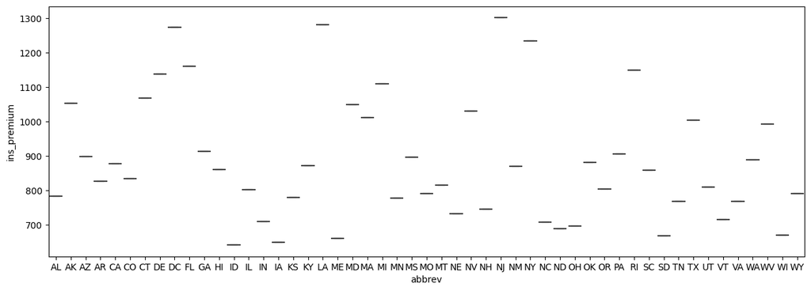

```python
fig, ax = plt.subplots(figsize=(15, 5))
sns.boxplot(x='abbrev', y='ins_premium', data=df, ax=ax)
```

This box plot will help you understand the distribution of insurance premiums across different states.

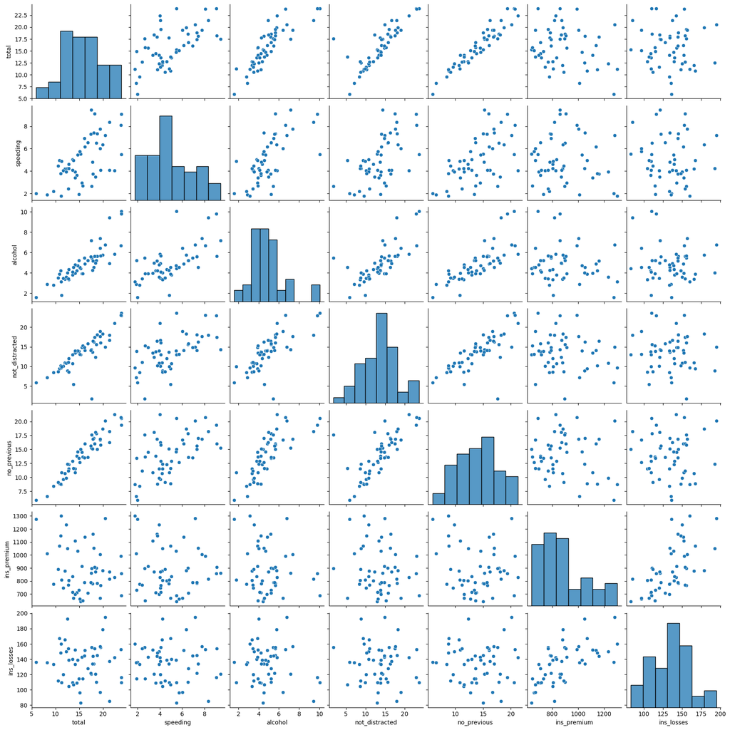

```python
sns.pairplot(df)
```

This plot provides scatterplots for all numeric variables in your dataset. You can observe the relationships between variables and identify potential patterns or trends. For example, you can see if there's any correlation between variables like 'total' and 'alcohol'.

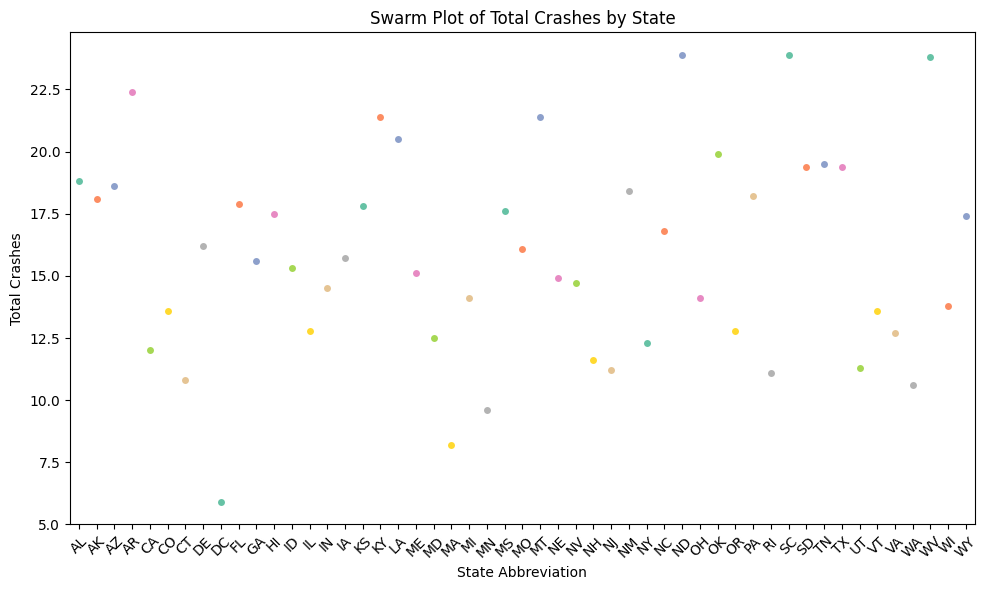

```python
plt.figure(figsize=(10, 6))
sns.swarmplot(x='abbrev', y='total', data=df, palette='Set2')
plt.xlabel('State Abbreviation')
plt.ylabel('Total Crashes')
plt.title('Swarm Plot of Total Crashes by State')
plt.xticks(rotation=45)
plt.tight_layout()
plt.show()
```

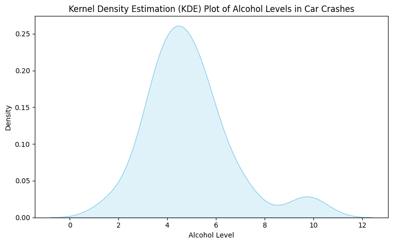

```python
plt.figure(figsize=(8, 5))
sns.kdeplot(df['alcohol'], shade=True, color='skyblue')
plt.xlabel('Alcohol Level')
plt.ylabel('Density')
plt.title('Kernel Density Estimation (KDE) Plot of Alcohol Levels in Car Crashes')
plt.tight_layout()
plt.show()
```

The KDE plot of alcohol levels in car crashes suggests that the majority of car crashes involve lower alcohol levels, with a right-skewed distribution.